# Math 185 Homework 2

### Question 2

```r
data <- rnorm(10000, 0, 1)
```

Type 1 computes the quantiles using the inverse of the empirical distribution function

```r
quantile(data, type=1)
```

```
##           0%          25%          50%          75%         100%
## -3.330016792 -0.667002404 -0.005033247  0.663587395  3.841937640
```

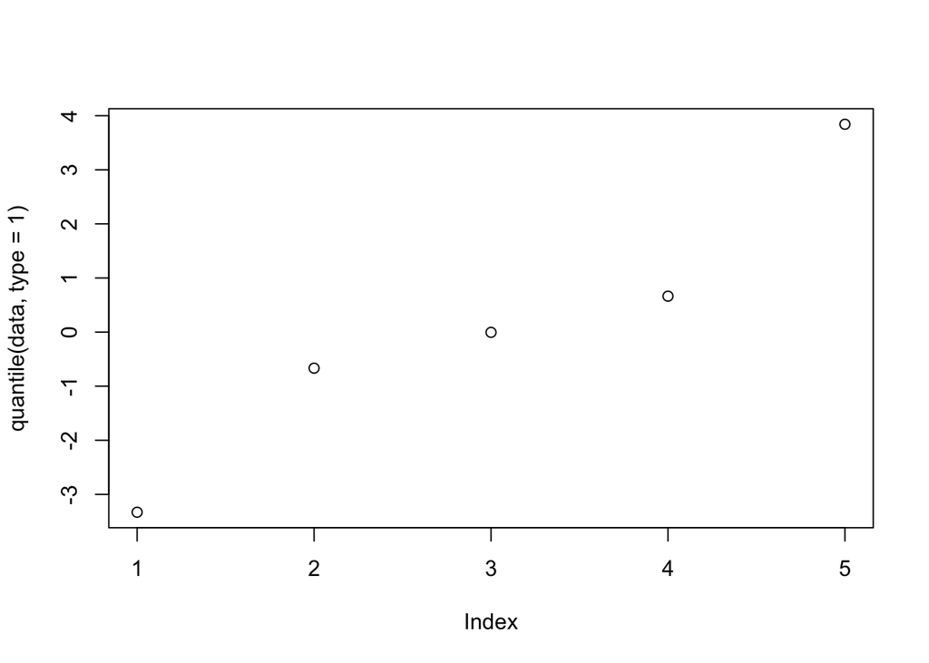

```r
plot(quantile(data, type=1))
```

Type 3 computes the quantiles using the nearest even order statistic.

```r
quantile(data, type=3)
```

```
##           0%          25%          50%          75%         100%
## -3.330016792 -0.667002404 -0.005033247  0.663587395  3.841937640
```

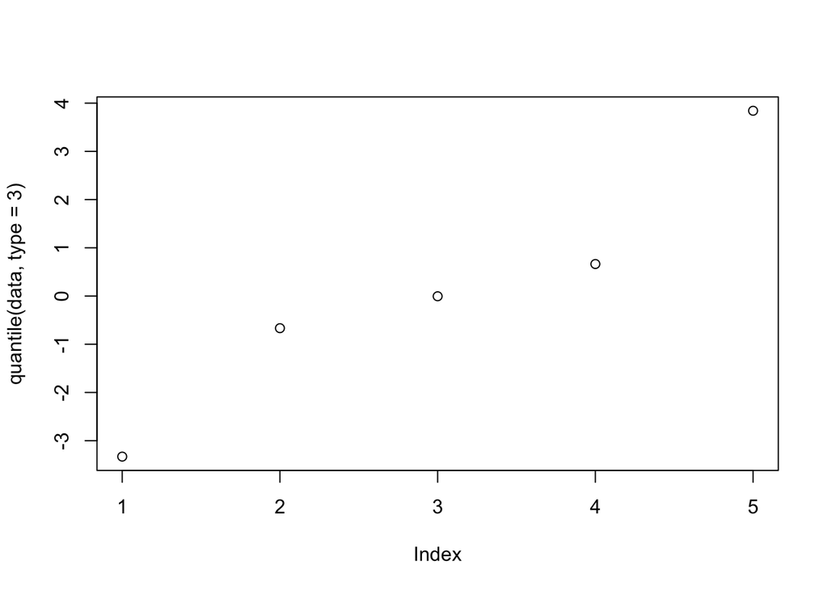

```r
plot(quantile(data, type=3))
```

In this case, the results are identical to that of type 1.

Type 4 calculates the quantiles via a linear interpolation of the empirical cdf.

```r
quantile(data, type=4)
```

```
##           0%          25%          50%          75%         100%
## -3.330016792 -0.667002404 -0.005033247  0.663587395  3.841937640
```

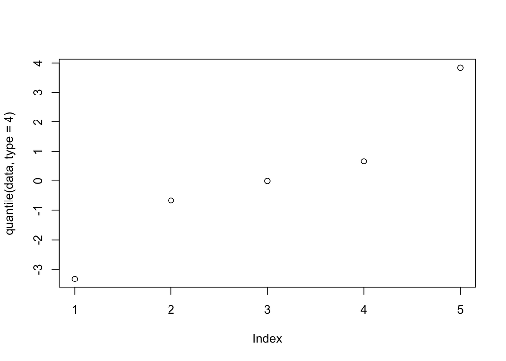

```r
plot(quantile(data, type=4))
```

Type 5 calculates the quantiles using a piecewise linear function where the knots are values midway through steps of the empirical cdf.

```r
quantile(data, type=5)
```

```
##          0%         25%         50%         75%        100%
## -3.33001679 -0.66679789 -0.00501535  0.66361528  3.84193764
```

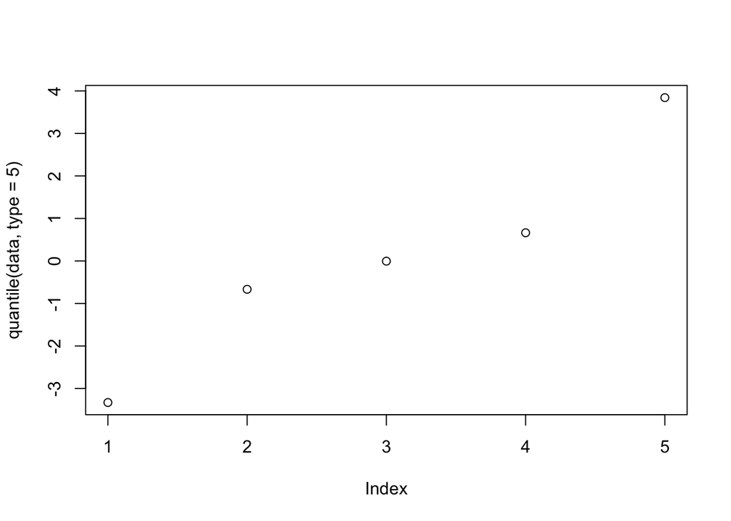

```r
plot(quantile(data, type=5))
```

Type 6 calculates quantiles using the expectation of the cdf.

```r
quantile(data, type=6)
```

```
##          0%         25%         50%         75%        100%
## -3.33001679 -0.66690015 -0.00501535  0.66362922  3.84193764
```

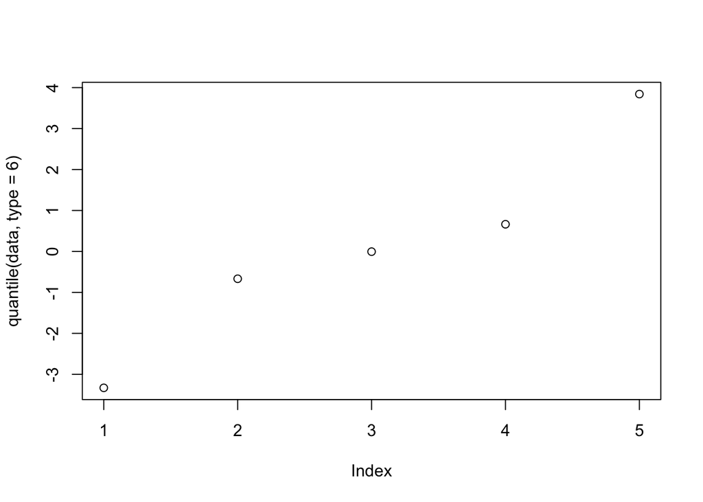

```r
plot(quantile(data, type=6))
```

### Question 3

```r
uniform.test <- function(x, B=10000) {
  a = min(x)
  b = max(x)
  D_0 = b - a
  tests = vector("numeric", B)
  for (b in 1:B) {
    sample_dist = sample(x, replace=TRUE)
    a_b = min(sample_dist)
    b_b = max(sample_dist)
    D_b = b_b - a_b
    tests[b] = D_b
  }
  p_value = (as.integer(tests >= D_0) + 1)/(B + 1)
  return(p_value)
}
```

In my function uniform.test, I define the test stat to be the difference of max and min of our original data. Then, I conduct a bootstrap where I repeatedly sample the data and create a boostrap statistic, the difference between the max and min of the sample data. Then I compute a p-value and return it.